# Coursework Report

*N* removed NAs: 3

*N* removed typo: 1

*N* removed <18: 23

*N* total clean: 123

| Group | *N* | *M*<sub>age</sub> | *M*<sub>rating</sub> |
| --- | --- | --- | --- |
| Control | 60 | 20.57 | 6.37 |
| Experim | 63 | 20.32 | 5.36 |

**Main analysis results**

*t*(121) = 6.59, *p* < .001

[interactive chart not shown]

[figure not shown]

[interactive chart not shown]

# Coursework Report

Analysing Data, Spring 2020

```
##    Min. 1st Qu.  Median    Mean 3rd Qu.    Max.    NA's
##    3.00   18.00   20.00   19.71   21.00   26.00       4
```

```
## [1] 2.633888
```

[output not shown]

```
##    Min. 1st Qu.  Median    Mean 3rd Qu.    Max.
##   18.00   19.00   20.00   20.44   21.00   26.00
```

```
## [1] 1.829388
```

```
## # A tibble: 2 x 2
##   condition    average
##   <fct>          <dbl>
## 1 control         6.37
## 2 experimental    5.36
```

```
##
##  Two Sample t-test
##
## data:  comp_questions by condition
## t = 6.5947, df = 121, p-value = 0.000000001178
## alternative hypothesis: true difference in means is not equal to 0
## 95 percent confidence interval:
##  0.7084953 1.3163724
## sample estimates:
##      mean in group control mean in group experimental
##                   6.372222                   5.359788
```

# *Methods*

### Participants

The original dataset contained information collected from 150 female participants. Their ages ranged from a reported 3 to 26 years, with a mean of 19.71 years. Due to ethical reasons, a total of 27 participants were removed from the original dataset for either providing no age (‘NA’) or for being under the age of 18 years (4 and 23 participants respectively).

The final dataset used in this study consisted of 123 female participants, with ages ranging from 18 to 26 years and a mean age of 20.44 years.

### Design

This article reinvestigates a study previously conducted by (Elliot, Kayser, Greitemeyer, & Lichtenfeld, 2010), which explored the question; ‘does the colour red influence a females’ perception of male attractiveness?’.

Replicating the previous study, the participants were shown a black and white image of a man on either a white or red background. The image was of the ‘head and upper torso of a moderately attractive young Caucasian man with brown hair, wearing a plaid shirt’. The participants were shown the image for an average of 5 seconds and then instructed to report the perceived attractiveness of the man on a 9-point rating scale; 1 (not at all attractive) and 9 (extremely attractive). The measurements were taken using three questions that can be assessed at face-validity; “How attractive do you think this person is?”, “How pleasant is this person to look at?”, and “If I were to meet the person in this picture face to face, I would think he is attractive”.

This study hypothesises that the participants in the experimental condition (red background) would, on average, rate the man as more attractive than those in the control condition (white background). A t-test made using the composite index made from the participants average rating score will be used to assess this prediction.

# *Results*

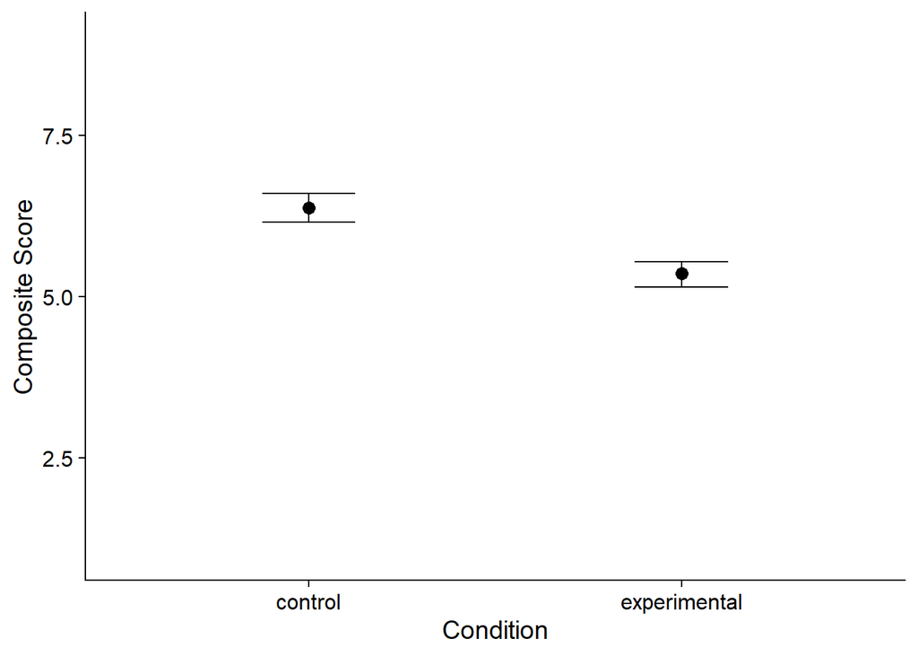

#### *Firgure 1. means plot by composite score by colour group.*

```
##
##  Two Sample t-test
##
## data:  comp_questions by condition
## t = 6.5947, df = 121, p-value = 0.000000001178
## alternative hypothesis: true difference in means is not equal to 0
## 95 percent confidence interval:
##  0.7084953 1.3163724
## sample estimates:
##      mean in group control mean in group experimental
##                   6.372222                   5.359788
```

#### *Figure 2. t-test analysing cmoposite score by condition.*

# *Discussion*

As explained in the results, it is evident that there is a clear correlation between the colour red and a females’ perceived attraction to men. However, unlike the original study, the colour red appears to have had an adverse effect on females’ attraction ratings. These findings challenge the findings in the original study conducted by (Elliot, Kayser, Greitemeyer, & Lichtenfeld, 2010) as they show a completely different effect of the colour red. Due to both this study and Elliot’s study showing strong correlations in conflicting directions, further investigations will need to be conducted in order to gain more insight into how exactly red effects females attraction.

Due to this, this article advises future investigations to focus on exploring the potential impact of cultural colour associations on females’ ratings of attractions. Future studies should also reinvestigate (Young, 2015) findings in order to assess and evaluate whether an initial attraction to the male is required in order to see the effects of the colour red. This investigation could also extend into exploring if having no initial attraction to the male influences an adverse rating on attraction.

# *References*

Elliot, A. J., Kayser, D. N., Greitemeyer, T., & Lichtenfeld, S. (2010). Red, Rank, and Romance in Women Viewing Men. Journal of Experimental Psychology: General, 399-417.

Young, S. G. (2015). The effect of red on male perceptions of female attractiveness: Moderation by baseline attractiveness of female faces. European Journal of Social Psycholog, Volume 45, Issue 2, 146-151.